# Helfand and House (1995)

Regulating nonpoint source pollution under heterogeneous conditions

AREC 615

October 8, 2026

## Why regulate inputs?

- Nitrate can leach below the crop root zone and reach groundwater.
- Effluent is difficult to measure and attribute to individual farms. (Nonpoint source pollution)
- Fertilizer and irrigation are potential *points* of regulation.

**The difficulty:** an input is observable more readily than its contribution to pollution.

## The cost of uniform regulation

Different soils imply different **yield responses** and **leaching responses**.

Tailored input instruments can implement the efficient allocation, but require more information and administration.

**The empirical question:** How much additional production cost does a common policy impose?

## Lettuce production on two soils

California’s Salinas Valley; equal areas of each soil.

| Unregulated outcome | Mocho | Pacheco |
| --- | --- | --- |
| Nitrogen applied (kg/ha) | 85 | 52 |
| Irrigation depth (mm) | 723 | 478 |
| Dry lettuce biomass (tons/ha) | 3.296 | 3.257 |
| Nitrate leaching (kg/ha) | 97 | 37 |

**Similar yields, very different input use and leaching.**

Published values: Tables 3–4, p. 1030. Irrigation is reported as “mm/ha” in the paper.

## Building the response functions

**EPIC simulations** → **estimated biological responses** → **economic optimization**

For soil $s$, estimate yield $Y_s(N_s,W_s)$ and leaching $L_s(N_s,W_s)$.

- Nitrogen and irrigation affect both outputs (lettuce yield and nitrate leaching).
- Nonlinear responses allow marginal effects to change with input use.
- The run a bunch of simulations and fit yield and leaching response functions.

Helfand and House (1995), pp. 1026–1028, Table 1.

## Yield and leaching responses

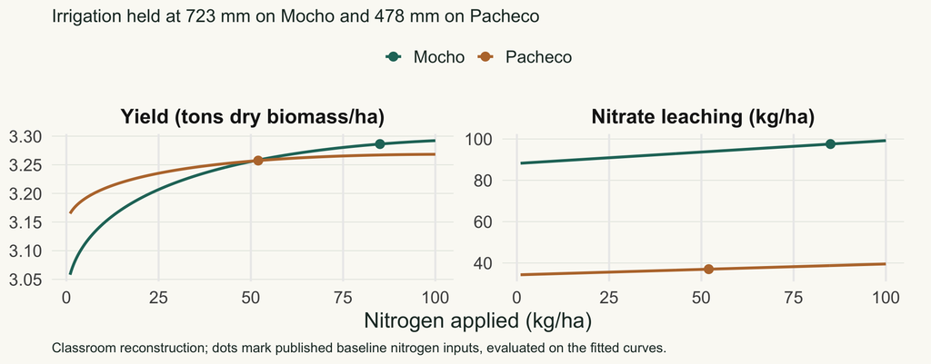

$$\begin{aligned}
Y_M(N,W)&=0.9117-0.00363N-0.0029W+1.93\!\times\!10^{-6}NW+0.0506\sqrt N+0.156\sqrt W\\
Y_P(N,W)&=2.296-0.00195N-0.00158W+1.53\!\times\!10^{-6}NW+0.0249\sqrt N+0.0732\sqrt W\\
L_M(N,W)&=-26.06-0.152N+0.158W+0.000363NW\\
L_P(N,W)&=43.82-0.17N+0.313W+0.000466NW-7.28\sqrt W
\end{aligned}$$

Working reconstruction: $M$ = Mocho, $P$ = Pacheco. Pacheco’s printed $-1.11\sqrt N$ term is omitted (unverified assumption).

## The farmer’s unregulated problem

For each soil $s\in\{M,P\}$:

$$\max_{N_s,W_s}\quad q_s=p_Y Y_s(N_s,W_s)-c_NN_s-c_WW_s$$

At an interior optimum:

$$p_Y Y_{s,N}=c_N,\qquad p_Y Y_{s,W}=c_W$$

**Marginal revenue product equals the input price.**

$p_Y=\$1{,}350$/ton; $c_N=\$0.70$/kg; $c_W=\$0.23$/mm-ha.  
Quasi-rent subtracts nitrogen and irrigation costs, not all farm costs.

## The least-cost pollution target

Choose $x=(N_M,W_M,N_P,W_P)$:

$$\max_x\;\sum_s a_s q_s(N_s,W_s)$$
$$\text{subject to}\quad \sum_s a_s L_s(N_s,W_s)\leq\bar L$$

Here $a_M=a_P=0.5$ and the intended target is **20% less leaching**.

A common target lets us compare production costs **without estimating a damage function**.

Model formulation; paper p. 1028. Classroom implementation sets $\bar L=0.8L^0$ exactly.  
Introduced $a_s$ to create equal weights so values are on a per-hectare basis.

## KKT conditions and the shadow value

$$\mathcal L=\sum_s a_s q_s+\lambda\left(\bar L-\sum_s a_sL_s\right)$$

For positive nitrogen and water choices on each soil $s\in\{M,P\}$:

$$\begin{aligned}
\text{Stationarity (nitrogen):}\quad &p_Y Y_{s,N}-c_N-\lambda L_{s,N}=0\\
\text{Stationarity (water):}\quad &p_Y Y_{s,W}-c_W-\lambda L_{s,W}=0\\
\text{Primal feasibility:}\quad &\sum_s a_sL_s(N_s,W_s)\leq\bar L\\
\text{Dual feasibility:}\quad &\lambda\geq0\\
\text{Complementary slackness:}\quad &\lambda\left(\bar L-\sum_s a_sL_s(N_s,W_s)\right)=0
\end{aligned}$$

## Implementing the efficient allocation

With input taxes, the farmer’s condition is

$$p_Y Y_{s,j}-c_j=t_{s,j}.$$

Matching the planner’s condition gives

$$\boxed{t_{s,j}=\lambda L_{s,j}(x_s^*)}.$$

**One pollution shadow value; potentially four input tax rates.**

The efficient rates differ when marginal leaching responses differ across soils.

## Seven policy experiments

| Policy | Common across soils? | Regulated inputs |
| --- | --- | --- |
| Differentiated taxes | No: soil-specific rates | Nitrogen and water |
| Uniform taxes on both inputs | Same two rates | Nitrogen and water |
| Uniform standard | Same percentage of own baseline | Nitrogen and water |
| Uniform nitrogen-only tax | Same rate | Nitrogen |
| Uniform water-only tax | Same rate | Water |
| Nitrogen standard | Same upper bound | Nitrogen |
| Water standard | Same upper bound | Water |

Paper pp. 1026, 1029. All policies aim at the same aggregate pollution target.

## Farmers respond to uniform input taxes

Each rate is common across soils; $t_N$ and $t_W$ need not be equal.

**Farmer:** choose nitrogen and water, $x_s=(N_s,W_s)$.

$$x_s(t_N,t_W)\in\arg\max_{N_s,W_s\geq0}
\left[q_s(N_s,W_s)-t_NN_s-t_WW_s\right]$$

**Regulator:** choose the two rates, anticipating farmer responses.

$$\begin{aligned}
\max_{t_N,t_W\geq0}\quad &\sum_s a_s q_s\big(x_s(t_N,t_W)\big)\\
\text{subject to}\quad &\sum_s a_sL_s\big(x_s(t_N,t_W)\big)\leq\bar L
\end{aligned}$$

A nitrogen tax can change **both** nitrogen and water use.

## Farmers respond to a common input ceiling

Example: a common irrigation ceiling $\bar W$ for both soils.

**Farmer:** maximize quasi-rent subject to the input ceiling.

$$x_s(\bar W)\in\arg\max_{\substack{N_s,W_s\geq0\\W_s\leq\bar W}}q_s(N_s,W_s)$$

**Regulator:** choose the ceiling, anticipating farmer responses.

$$\begin{aligned}
\max_{\bar W\geq0}\quad &\sum_s a_s q_s\big(x_s(\bar W)\big)\\
\text{subject to}\quad &\sum_s a_sL_s\big(x_s(\bar W)\big)\leq\bar L
\end{aligned}$$

Same ceiling, potentially different use: $W_M\leq\bar W$ and $W_P\leq\bar W$.

## Efficiency costs and farmer payments

$$C=\sum_s a_s\left[q_s(x_s^0)-q_s(x_s^{policy})\right]$$

**Production loss** counts as an efficiency cost.

**Tax revenue** is a transfer in this accounting.

$$\text{Farmer net receipts}=\text{pre-tax quasi-rent}-\text{tax payments}$$

## Several uniform policies nearly match the benchmark

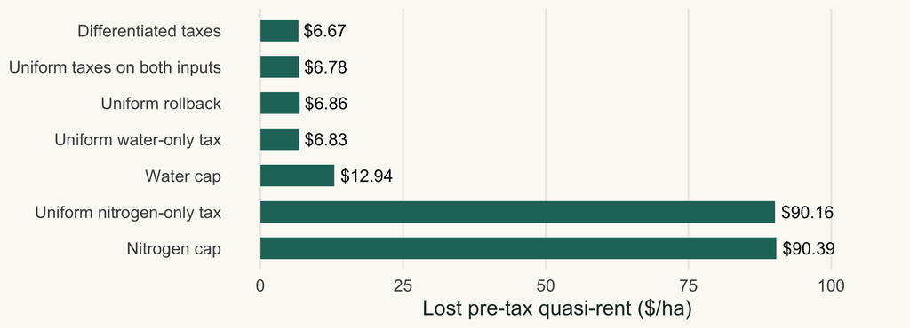

Near the benchmark: **$6.67** differentiated · **$6.78** uniform taxes · **$6.83** water tax · **$6.86** rollback

Published results, Table 2, p. 1029; nominal dollars as reported in the paper.

## Why nitrogen-only controls cost more

| Published response | Mocho | Pacheco |
| --- | --- | --- |
| Nitrogen, baseline → N tax (kg/ha) | 85 → 12 | 52 → 4 |
| Water, baseline → water tax (mm) | 723 → 650 | 478 → 402 |
| Yield loss under N tax (tons/ha) | 0.136 | 0.077 |
| Yield loss under water tax (tons/ha) | 0.021 | 0.021 |

The nitrogen tax requires a drastic fertilizer reduction; the water tax achieves the target with much smaller yield losses.

Published Tables 3–4, p. 1030; yield losses calculated from rounded reported yields.

## Who bears the cost?

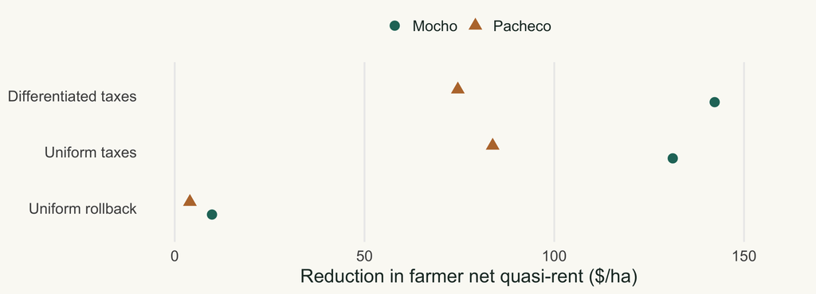

Tax payments make farmer losses much larger than production-efficiency costs. Rollback collects no tax revenue.

Calculated from published net quasi-rents, Tables 3–4. No tax rebates assumed.

## What the results establish

**Several simple policies perform well in this application.**

- The regulated input matters greatly for production costs.
- Small efficiency differences can coexist with large differences in farmer receipts.
- Administration and enforcement costs could change the ranking.

Two soils, fixed prices, and fitted biological responses limit generalization.

## The classroom model and numerical checks

The supplied R code is a **documented reconstruction**, with explicit assumptions where the printed paper is inconsistent.

Before interpreting a solution, check:

1. Does each policy meet the same pollution target?
2. Do farmer choices and the efficient benchmark satisfy their optimality conditions?
3. Does a small change in the cap agree with the shadow value?
4. Do alternative starting values lead to the same solution?

Course files: `Helfand_Notes.qmd`, and `HH_model.R`

## Extend the model

Choose one economically meaningful addition:

| Extension | Economic question |
| --- | --- |
| Water scarcity | How do water and pollution shadow values interact? |
| Irrigation technology | When is adoption worthwhile, and how does policy affect it? |
| Implementation costs | When does differentiation justify its added cost? |
| Land allocation | How does an outside option change abatement? |

**Show:** a revised model, one central comparison, the mechanism, and checks.

## Backup: response functions and coefficients

For yield or leaching:

$$F_s=b_{0s}+b_{Ns}N_s+b_{Ws}W_s+b_{NWs}N_sW_s+b_{\sqrt N,s}\sqrt{N_s}+b_{\sqrt W,s}\sqrt{W_s}$$

| Printed Table 1 | $b_0$ | $b_N$ | $b_W$ | $b_{NW}$ | $b_{\sqrt N}$ | $b_{\sqrt W}$ |
| --- | --- | --- | --- | --- | --- | --- |
| Mocho yield | 0.9117 | **0.00363** | −0.0029 | 0.00000193 | 0.0506 | 0.156 |
| Pacheco yield | 2.296 | −0.00195 | −0.00158 | 0.00000153 | 0.0249 | 0.0732 |
| Mocho leaching | −26.06 | −0.152 | 0.158 | 0.000363 | 0 | 0 |
| Pacheco leaching | 43.82 | −0.17 | 0.313 | 0.000466 | **−1.11** | −7.28 |

$$F_{s,N}=b_{Ns}+b_{NWs}W_s+\frac{b_{\sqrt N,s}}{2\sqrt{N_s}}$$

Working reconstruction changes the bold entries to **−0.00363** and **0**, respectively. These choices are not author-confirmed corrections.

Table 1, p. 1028; reconstruction choices documented in the course model notes.

## Backup: published results and reconstruction

| Issue | Published source | Classroom treatment |
| --- | --- | --- |
| Mocho yield coefficient | Positive N coefficient; negative t-statistic | Use negative coefficient; strong internal evidence |
| Pacheco leaching term | $-1.11\sqrt N$ conflicts with reported baseline leaching | Omit term as an **unverified hypothesis** |
| Water standard | Printed cap 478; Mocho use 585 | Solve for a feasible common cap |
| Pollution target | Baseline 67; target 53.1 | Use exactly 80% of computed baseline |

The reference code is **not an exact replication**. Remaining differences include baseline quasi-rent and nitrogen-only policy costs.

Policy-result charts use **published Tables 2–4**. Response curves and lab comparisons use the **documented computational reference**.

Helfand and House (1995), Tables 1–4; course README.md and Helfand_Notes.qmd source audit.